# STAT 413/613: HW on List Columns and COVID19

Jaehee Lee

2021-05-04

# Instructions

1. Clone this homework repo to your homework directory as a new repo.
2. Rename the starter file under the analysis directory as `hw_01_yourname.Rmd` and use it for your solutions.
3. Modify the “author” field in the YAML header.
4. Stage and Commit R Markdown and HTML files (no PDF files).
5. **Push both .Rmd and HTML files to GitHub**.
- Make sure you have knitted to HTML prior to staging, committing, and pushing your final submission.
6. **Commit each time you answer a part of question, e.g. 1.1**
7. **Push to GitHub after each major question**
8. When complete, submit a response in Canvas
- Only include necessary code to answer the questions.
- Most of the functions you use should be from the tidyverse. Unnecessary Base R or other packages not covered in class will result in point deductions.
- Use Pull requests and or email to ask me any questions. If you email, please ensure your most recent code is pushed to GitHub.
- **Learning Outcome**
  - Use tidyverse functions to create, clean, tidy, and manipulate data frames in a list column
  - Apply purrr functions when working with list columns
  - Employ joins to manipulate data from multiple data frames
- **Context**
  - This assignment looks at COVID-19 data based on the most recent data as of the date you do the work.

Load library

```r
library(tidyverse)
```

# 1 Load global and US confirmed cases and deaths data into a nested data frame

1. Create a variable called `url_in` to store this URL: “https://raw.githubusercontent.com/CSSEGISandData/COVID-19/master/csse_covid_19_data/csse_covid_19_time_series/”. This allows you do directly download the files at the John’s Hopkins site: “https://github.com/CSSEGISandData/COVID-19/tree/master/csse_covid_19_data/csse_covid_19_time_series”

```r
url_in <- "https://raw.githubusercontent.com/CSSEGISandData/COVID-19/master/csse_covid_19_data/csse_covid_19_time_series/"
```

2. Create a tibble named `df` with a variable called `file_names` with a row for each of the following four file names to be loaded from the URL:
   - time_series_covid19_confirmed_global.csv
   - time_series_covid19_deaths_global.csv
   - time_series_covid19_confirmed_US.csv
   - time_series_covid19_deaths_US.csv

```r
df <- tibble(
 file_names =
   c('time_series_covid19_confirmed_global.csv',
  'time_series_covid19_deaths_global.csv',
  'time_series_covid19_confirmed_US.csv',
  'time_series_covid19_deaths_US.csv')
)
```

3. Create a variable in the data frame called `url` that puts `url_in` on the front of each file_name to create a complete URL.

```r
df %>%
  mutate(url = str_c(url_in, file_names, sep = '')) -> df
```

4. Use `mutate()` with `map()` to create a list column called `data` with each row holding the downloaded data frame for each file name

```r
df %>%
  mutate(data = map(url, read_csv)) -> df
```

5. Add a factor variable to `df` called `"`case_type`"` with the **unique** portions of the file names.

```r
df %>%
  mutate(case_types = as_factor(str_extract(file_names,"[:alpha:]*_[gU][:alpha:]*"))) -> df
```

6. Remove any columns other than `case_types` and `data` from `df`.
- `df` should have four observations of two variables.

```r
df %>%
  select("case_types", "data" ) -> df
```

# 2 Clean Data

1. Using a single call to `map()`, add only the first 15 names from each of the four data frames to a new variable in `df` called `vars`.
- Visually compare them to identify issues across the rows.

```r
df %>%
  mutate(vars = map(df$data, names)) -> df
df %>%
  mutate(vars = map(df$vars, ~unlist(.)[1:15]))
```

```
## # A tibble: 4 x 3
##   case_types       data                              vars
##   <fct>            <list>                            <list>
## 1 confirmed_global <spec_tbl_df[,472] [275 × 472]>   <chr [15]>
## 2 deaths_global    <spec_tbl_df[,472] [275 × 472]>   <chr [15]>
## 3 confirmed_US     <spec_tbl_df[,479] [3,342 × 479]> <chr [15]>
## 4 deaths_US        <spec_tbl_df[,480] [3,342 × 480]> <chr [15]>
```

2. Use a purrr function for each of the following steps (except a) to fix any issues and create consistent data frames.
1. Create a short helper function called `fix_names()` which takes three arguments: a data frame, a string pattern, and a string “replacement pattern”. It should replace all occurrences of the “string pattern” in the names of the variables in the data frame with the “replacement pattern”. Include error checking to ensure the inputs are of the proper class.

```r
fix_names <- function(dataframe, string_pattern, replacement_pattern) {
  stopifnot(is.data.frame(dataframe))
  stopifnot(is.character(string_pattern))
  stopifnot(is.character(replacement_pattern))

  names(dataframe) = str_replace_all(names(dataframe), string_pattern, replacement_pattern)

  return(dataframe)
}
```

2. Use your function with `map()` to convert “Province/State” and “Country/Region” to “Province_State” “Country_Region” .

```r
df %>%
  mutate(data = map(data, ~fix_names(. , "([ey])/", "\\1_"))) -> df
```

3. Use your function with `map()` to convert “Admin2 to”County" and “Long_” to “Long”.

```r
df %>%
  mutate(data = map(data, ~fix_names(. , "Admin2", "County" ))) %>%
  mutate(data = map(data, ~fix_names(. , "Long_", "Long") ))-> df
```

4. Use a purrr function to remove the variables “UID”, “iso2”, “iso3”, “code3”, “FIPS”, and “Combined_Key” from only the US data.

```r
df %>%
  mutate(data = map_if(data, str_detect(df$case_types, "_US"), ~select(.,-c("UID", "iso2", "iso3", "code3", "FIPS", "Combined_Key")))) -> df
```

5. Use a purrr function to add variables `Population` and `County` to the data frames where missing.

```r
map_if(df$data, ~!'Population'%in% colnames(.), ~mutate(. ,Population = 1 )) -> df$data
map_if(df$data, ~!'County'%in% colnames(.), ~mutate(. ,County = 1 )) -> df$data
```

6. Use a purrr function to add variable called `Country_State` that combines the country with the province/state while keeping the original columns.

```r
map(df$data, ~ mutate(., Country_State = str_c(.$Province_State, .$Country_Region, sep = "_"))) -> df$data
```

7. Update the values in `df$vars` with the new first 15 names and show the values to check for consistency in each pair of rows.

```r
df %>%
  mutate(vars = map(df$data, names)) %>%
  mutate(vars = map(df$vars, ~unlist(.)[1:15])) -> df
df$vars
```

```
## [[1]]
##  [1] "Province/State" "Country/Region" "Lat"            "Long"
##  [5] "1/22/20"        "1/23/20"        "1/24/20"        "1/25/20"
##  [9] "1/26/20"        "1/27/20"        "1/28/20"        "1/29/20"
## [13] "1/30/20"        "1/31/20"        "2/1/20"
##
## [[2]]
##  [1] "Province/State" "Country/Region" "Lat"            "Long"
##  [5] "1/22/20"        "1/23/20"        "1/24/20"        "1/25/20"
##  [9] "1/26/20"        "1/27/20"        "1/28/20"        "1/29/20"
## [13] "1/30/20"        "1/31/20"        "2/1/20"
##
## [[3]]
##  [1] "UID"            "iso2"           "iso3"           "code3"
##  [5] "FIPS"           "Admin2"         "Province_State" "Country_Region"
##  [9] "Lat"            "Long_"          "Combined_Key"   "1/22/20"
## [13] "1/23/20"        "1/24/20"        "1/25/20"
##
## [[4]]
##  [1] "UID"            "iso2"           "iso3"           "code3"
##  [5] "FIPS"           "Admin2"         "Province_State" "Country_Region"
##  [9] "Lat"            "Long_"          "Combined_Key"   "Population"
## [13] "1/22/20"        "1/23/20"        "1/24/20"
```

# 3 Tidy each dataframe

1. Use `map()` along with `pivot_longer()` to tidy each data frame.
- As part of the pivot, ensure the daily values are in a variable called “`Date`” and use a lubridate function *inside the pivot* to ensure it is of class `date`.
2. Save the new data frame to a variable called `df_long`

```r
library(lubridate)
```

```r
# change df to df_long
df_long <- df

map(df_long$data, ~ pivot_longer(., cols = -c("County", "Province_State", "Country_Region", "Lat", "Long", "Population", "Country_State"), names_to = "Date", values_to = "cases", names_transform = list(Date=mdy)) ) -> df_long$data
```

# 4 Add Continents

1. Use `map()` to add a new variable called `Continent` to each data frame.
- Hint: use the package {countrycode} to get the continents.
- If you don’t have it already, use the console to install.
- Then load package {countrycode} and look at help for `countrycode::countrycode`
- You will get some warning messages about NAs which you will fix next.

```r
library(countrycode)
df_long %>%
  mutate(data = map(data, ~mutate(., Continent = countrycode(Country_Region,
                                               origin = "country.name",
                                               destination = "continent")))) -> df_long
```

```
## Warning in countrycode(Country_Region, origin = "country.name", destination = "continent"): Some values were not matched unambiguously: Diamond Princess, Kosovo, Micronesia, MS Zaandam

## Warning in countrycode(Country_Region, origin = "country.name", destination = "continent"): Some values were not matched unambiguously: Diamond Princess, Kosovo, Micronesia, MS Zaandam
```

# 5 Fix NAs for Continents

- Use `map()` with `case_when()` to replace the NAs due to “Diamond Princess”, “Kosovo”, “MS Zaandam” and Micronesia, with the most appropriate continent

```r
df_long %>%
  mutate(data = map(data, ~ mutate(., Continent = case_when(
    Country_Region == "Diamond Princess" ~ "Asia",
    Country_Region == "Kosovo" ~ "Americas",
    Country_Region == "MS Zaandam" ~ "Europe",
    Country_Region == "Micronesia" ~ "Oceania",
    TRUE ~ Continent))))  -> df_long
```

- Use `map()` with `unique()` to confirm five continents in the global data frames and one in the US data frames

```r
map(df_long$data, ~unique(.  $Continent))
```

```
## [[1]]
## [1] "Asia"     "Europe"   "Africa"   "Americas" "Oceania"
##
## [[2]]
## [1] "Asia"     "Europe"   "Africa"   "Americas" "Oceania"
##
## [[3]]
## [1] "Americas"
##
## [[4]]
## [1] "Americas"
```

# 6 Unnest the Data Frames

1. Unnest and ungroup the data frame `df_long` and save into a new data frame called `df_all`

```r
df_long$data[[1]]$County <- as.character(df_long$data[[1]]$County)
df_long$data[[2]]$County <- as.character(df_long$data[[2]]$County)
df_long$data[[3]]$County <- as.character(df_long$data[[3]]$County)
df_long$data[[4]]$County <- as.character(df_long$data[[4]]$County)

df_long %>%
  unnest(cols = data) %>%
  ungroup() -> df_all
```

2. Remove original `df` and `df_long` dataframes from the environment

```r
remove(df, df_long)
```

3. Remove the `vars` variable from df_all

```r
df_all %>%
  select(-vars) -> df_all
```

# 7 Get World Population Data

1.a. Use a readr function and relative path to read in the .csv with World population data for 2019 into its own data frame called `df_pop`.

- The data is from the [UN](https://population.un.org/wpp/Download/Standard/CSV/) which uses different country names in many cases from the COVID data. It also uses a different structure for separating countries and territories.
- The CSV has been adjusted to match the COVID data country names in many cases, e.g., US, and Iran.
- Note: the UN population data is in thousands so it can have fractional values.

```r
df_pop <- read_csv("data/WPP2019_TotalPopulation.csv")
```

1.b. Identify the countries in the Covid data that are not in the population data.

```r
a <- unique(df_all$Country_Region)
b <- unique(df_pop$Location)
setdiff(a,b)
```

```
## [1] "Diamond Princess" "Kosovo"           "MS Zaandam"
```

1.c. Identify the countries in the population data that are not in the covid data. How many are there?

```r
a <- unique(df_all$Country_Region)
b <- unique(df_pop$Location)
length(a)  < length(b)
```

```
## [1] TRUE
```

1.d. What is the percentage of the world population contained in these countries? - Since the percentage is small, we will remove them from the subsequent analysis.

```r
total_population <- sum(df_pop$PopTotal)
df_pop %>%
  mutate(percen_world_pop = PopTotal/ total_population) -> df_pop
```

2. Use a dplyr join to remove all Locations that are not in the `df_all` data frame.

```r
semi_join(df_pop, df_all, by = c("Location" = "Country_Region")) -> df_pop
```

3. Use a dplyr function to add the ranks for each location for population and population density to `df_pop` where the country with the largest value is number 1 for that variables. Show the top 10 countries for Population and for population density.
- Calculate the ranks using a method where if `n` countries are tied at the same rank, the next rank is `n` greater than the rank with if the ties. As an example, if two countries are tied at 2, the next non-tied country has rank 4.

```r
df_pop %>%
  mutate(rank_p = rank(-PopTotal, na.last = TRUE),
         rank_d = rank(-PopDensity, na.last = TRUE),
         PopTotal = (PopTotal*1000)) -> df_pop
df_pop %>%
  slice_min(rank_p, n = 10)
```

```
## # A tibble: 10 x 7
##    LocID Location     PopTotal PopDensity percen_world_pop rank_p rank_d
##    <dbl> <chr>           <dbl>      <dbl>            <dbl>  <dbl>  <dbl>
##  1   156 China      1433783692     153.             0.186       1     56
##  2   356 India      1366417756     460.             0.177       2     17
##  3   840 US          329064917      36.0            0.0427      3    141
##  4   360 Indonesia   270625567     149.             0.0351      4     57
##  5   586 Pakistan    216565317     281.             0.0281      5     32
##  6    76 Brazil      211049519      25.3            0.0274      6    151
##  7   566 Nigeria     200963603     221.             0.0261      7     46
##  8    50 Bangladesh  163046173    1253.             0.0211      8      7
##  9   643 Russia      145872260       8.91           0.0189      9    176
## 10   484 Mexico      127575529      65.6            0.0165     10    115
```

```r
df_pop %>%
  slice_min(rank_d, n = 10)
```

```
## # A tibble: 10 x 7
##    LocID Location            PopTotal PopDensity percen_world_pop rank_p rank_d
##    <dbl> <chr>                  <dbl>      <dbl>            <dbl>  <dbl>  <dbl>
##  1   492 Monaco                 38967     26152.      0.00000505     186      1
##  2   702 Singapore            5804343      8292.      0.000752       111      2
##  3    48 Bahrain              1641164      2159.      0.000213       148      3
##  4   336 Holy See                 815      1852.      0.000000106    189      4
##  5   462 Maldives              530957      1770.      0.0000688      166      5
##  6   470 Malta                 440377      1376.      0.0000571      167      6
##  7    50 Bangladesh         163046173      1253.      0.0211           8      7
##  8   275 West Bank and Gaza   4981422       827.      0.000646       118      8
##  9   158 Taiwan*             23773881       671.      0.00308         55      9
## 10   422 Lebanon              6855709       670.      0.000889       106     10
```

4. Create an appropriate plot and then test to assess if there is a linear relationship between ranks for Total Population and Population Density. Interpret the plot and interpret the output from the model in terms of `$p$` value and adjusted R-squared.

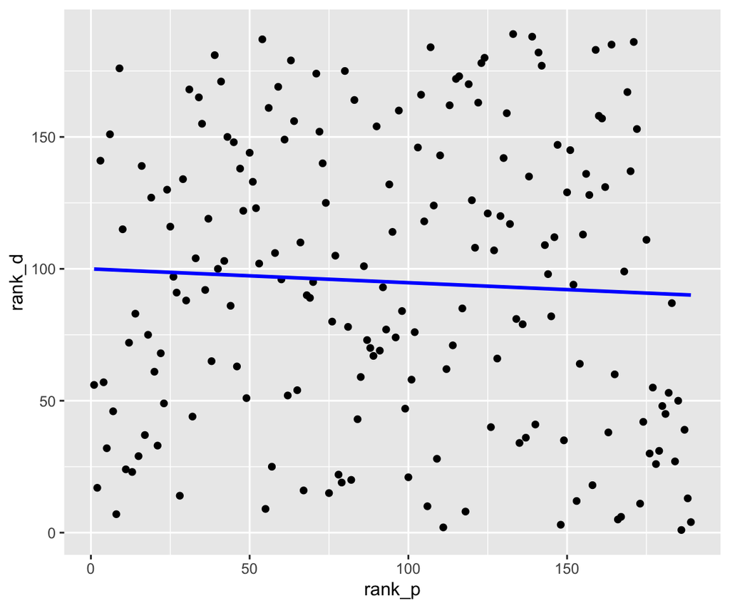

```r
ggplot(df_pop, aes(x = rank_p, y = rank_d))+
  geom_point()+
  geom_smooth(method = "lm",
                    se = F,
                    color = "blue")
```

```r
lmout <-lm(rank_p ~ rank_d, data = df_pop)
summary(lmout)
```

```
##
## Call:
## lm(formula = rank_p ~ rank_d, data = df_pop)
##
## Residuals:
##     Min      1Q  Median      3Q     Max
## -97.083 -45.749   0.937  48.868  89.236
##
## Coefficients:
##             Estimate Std. Error t value Pr(>|t|)
## (Intercept) 99.97298    8.00026  12.496   <2e-16 ***
## rank_d      -0.05235    0.07303  -0.717    0.474
## ---
## Signif. codes:  0 '***' 0.001 '**' 0.01 '*' 0.05 '.' 0.1 ' ' 1
##
## Residual standard error: 54.77 on 187 degrees of freedom
## Multiple R-squared:  0.00274,    Adjusted R-squared:  -0.002593
## F-statistic: 0.5138 on 1 and 187 DF,  p-value: 0.4744
```

Interpretation: We can see that the blue linear line is very close to horizontal to x- axis. What this indicates is that there is no relationship between rank_p and rank_d. Since p value is 0.4744 which is bigger than 0.05, means this is not statistically significant. Furthermore, adjusted r-squared appears to be negative. “Because R-square is defined as the proportion of variance explained by the fit, if the fit is actually worse than just fitting a horizontal line then R-square is negative.”

# 8 Add Population Data to `df_all`

- Use a dplyr join to add the data from `df_pop` to `df_all` to create `df_allp`
- This means there will be two columns with population data:
  - `Population` for US Counties
  - `PopTotal` for the country level

```r
df_all %>%
  inner_join(df_pop, by = c("Country_Region" = "Location")) -> df_allp
df_allp
```

```
## # A tibble: 3,382,704 x 17
##    case_types       Province_State Country_Region   Lat  Long Population County
##    <fct>            <chr>          <chr>          <dbl> <dbl>      <dbl> <chr>
##  1 confirmed_global <NA>           Afghanistan     33.9  67.7          1 1
##  2 confirmed_global <NA>           Afghanistan     33.9  67.7          1 1
##  3 confirmed_global <NA>           Afghanistan     33.9  67.7          1 1
##  4 confirmed_global <NA>           Afghanistan     33.9  67.7          1 1
##  5 confirmed_global <NA>           Afghanistan     33.9  67.7          1 1
##  6 confirmed_global <NA>           Afghanistan     33.9  67.7          1 1
##  7 confirmed_global <NA>           Afghanistan     33.9  67.7          1 1
##  8 confirmed_global <NA>           Afghanistan     33.9  67.7          1 1
##  9 confirmed_global <NA>           Afghanistan     33.9  67.7          1 1
## 10 confirmed_global <NA>           Afghanistan     33.9  67.7          1 1
## # … with 3,382,694 more rows, and 10 more variables: Country_State <chr>,
## #   Date <date>, cases <dbl>, Continent <chr>, LocID <dbl>, PopTotal <dbl>,
## #   PopDensity <dbl>, percen_world_pop <dbl>, rank_p <dbl>, rank_d <dbl>
```

# 9 How many Country Regions have Multiple Country States?

- Calculate the number of Country States for each Country Region

```r
df_allp %>%
  select(Country_Region, Country_State) %>%
  distinct() %>%
  group_by(Country_Region) %>%
  summarise(count = n()) %>%
  filter(count> 1) %>%
  nrow()
```

```
## [1] 8
```

- Show in descending order of the number of Country_States by Country_Region.

```r
df_allp %>%
  select(Country_Region, Country_State) %>%
  distinct() %>%
  group_by(Country_Region) %>%
  summarise(count = n()) %>%
  arrange(desc(count)) -> states_region
# check
head(states_region)
```

```
## # A tibble: 6 x 2
##   Country_Region count
##   <chr>          <int>
## 1 US                59
## 2 China             34
## 3 Canada            16
## 4 France            12
## 5 United Kingdom    12
## 6 Australia          8
```

# 10 Analyse Data

1. Create a data frame by with data grouped by `Country_Region`, `Continent` `case_type`, `rank_p` and `rank_d` that summarizes the current totals and the totals as a percentage of total population.
- Be sure to look at how the data is reported so the numbers make sense.

```r
df_allp %>%
 group_by(Country_Region, Continent, case_types, rank_p, rank_d) %>%
 summarise(current_totals = max(cases), percentage_total_pop = current_totals/last(PopTotal)*100) %>%
  ungroup() -> df_with_summarize
```

2. What are the 20 Countries with the most confirmed cases and what is the percentage of their total population affected?

```r
df_with_summarize %>%
filter(case_types == "confirmed_global") %>%
arrange(desc(current_totals)) %>%
  head(20) %>%
  select(Country_Region, current_totals, percentage_total_pop, rank_p, rank_d) -> countries20_confirmed
countries20_confirmed
```

```
## # A tibble: 20 x 5
##    Country_Region current_totals percentage_total_pop rank_p rank_d
##    <chr>                   <dbl>                <dbl>  <dbl>  <dbl>
##  1 US                   32470920                9.87       3    141
##  2 India                19925604                1.46       2     17
##  3 Brazil               14779529                7.00       6    151
##  4 France                5609292                8.61      22     68
##  5 Turkey                4900121                5.87      18     75
##  6 Russia                4776844                3.27       9    176
##  7 United Kingdom        4421850                6.55      21     33
##  8 Italy                 4050708                6.69      23     49
##  9 Spain                 3540430                7.58      30     88
## 10 Germany               3438186                4.12      17     37
## 11 Argentina             3021179                6.75      31    168
## 12 Colombia              2905254                5.77      29    134
## 13 Poland                2805756                7.41      38     65
## 14 Iran                  2555587                3.08      19    127
## 15 Mexico                2349900                1.84      10    115
## 16 Ukraine               2140838                4.87      33    104
## 17 Peru                  1814127                5.58      43    150
## 18 Indonesia             1682004                0.622      4     57
## 19 Czechia               1634619               15.3       85     59
## 20 South Africa          1584961                2.71      24    130
```

3. What are the 20 Countries with the most deaths and what is the percentage of their total population affected?

```r
df_with_summarize %>%
filter(case_types == "deaths_global") %>%
  arrange(desc(current_totals)) %>%
  head(20) %>%
  select(Country_Region, current_totals, percentage_total_pop, rank_p, rank_d)-> countries20_deaths
countries20_deaths
```

```
## # A tibble: 20 x 5
##    Country_Region current_totals percentage_total_pop rank_p rank_d
##    <chr>                   <dbl>                <dbl>  <dbl>  <dbl>
##  1 US                     577500               0.175       3    141
##  2 Brazil                 408622               0.194       6    151
##  3 India                  218959               0.0160      2     17
##  4 Mexico                 217345               0.170      10    115
##  5 United Kingdom         127539               0.189      21     33
##  6 Italy                  121433               0.201      23     49
##  7 Russia                 109341               0.0750      9    176
##  8 France                 104404               0.160      22     68
##  9 Germany                 83605               0.100      17     37
## 10 Spain                   78293               0.168      30     88
## 11 Colombia                75164               0.149      29    134
## 12 Iran                    72875               0.0879     19    127
## 13 Poland                  68105               0.180      38     65
## 14 Argentina               64792               0.145      31    168
## 15 Peru                    62375               0.192      43    150
## 16 South Africa            54452               0.0930     24    130
## 17 Ukraine                 46607               0.106      33    104
## 18 Indonesia               45949               0.0170      4     57
## 19 Turkey                  41191               0.0494     18     75
## 20 Czechia                 29365               0.275      85     59
```

4. Describe the results based on the totals with the rankings for total population and population density. Interpretation: US has the highest confirmed cases and deaths among all countries. Eventhough the rankings for total_population is 3rd ranking and rankings for population density is 141 rankings.

# 11 Which countries in the top 20 for percentage of population for cases are Not in the top 20 for the absolute number of cases. Which countries in the top 20 for percentage of population for deaths are Not in the top 20 for the absolute number deaths?

```r
countries20_confirmed %>%
   select(Country_Region) %>%
  list()-> confirmed_20

df_with_summarize %>%
  filter(case_types == "confirmed_global") %>%
  arrange(desc(percentage_total_pop)) %>%
  head(20) %>%
  select(Country_Region) %>%
  list()-> perc20

setdiff(perc20[[1]], confirmed_20[[1]])
```

```
## # A tibble: 17 x 1
##    Country_Region
##    <chr>
##  1 Andorra
##  2 Montenegro
##  3 San Marino
##  4 Slovenia
##  5 Bahrain
##  6 Luxembourg
##  7 Israel
##  8 Sweden
##  9 Estonia
## 10 Lithuania
## 11 Netherlands
## 12 Belgium
## 13 Panama
## 14 Portugal
## 15 Croatia
## 16 Hungary
## 17 Serbia
```

```r
countries20_deaths %>%
   select(Country_Region) %>%
  list()-> deaths_20

df_with_summarize %>%
    filter(case_types == "deaths_global") %>%
  arrange(desc(percentage_total_pop)) %>%
  head(20) %>%
  select(Country_Region) %>%
  list()-> perc_deaths_20

setdiff(deaths_20[[1]], perc_deaths_20[[1]])
```

```
## # A tibble: 11 x 1
##    Country_Region
##    <chr>
##  1 India
##  2 Russia
##  3 France
##  4 Germany
##  5 Colombia
##  6 Iran
##  7 Argentina
##  8 South Africa
##  9 Ukraine
## 10 Indonesia
## 11 Turkey
```

- Describe the results based on the per population results with the rankings for total population and population density.

# 12 Create two plots, one for the number of cases and one for the number of deaths over time for the top 20 country/region showing each country and faceting by continent with the same scale for the y axis.

- Use appropriate scales for the axes.
- Create two sets of plots
- Interpret each plot with respect to the total cases/deaths and the path of cases/deaths across different continents.

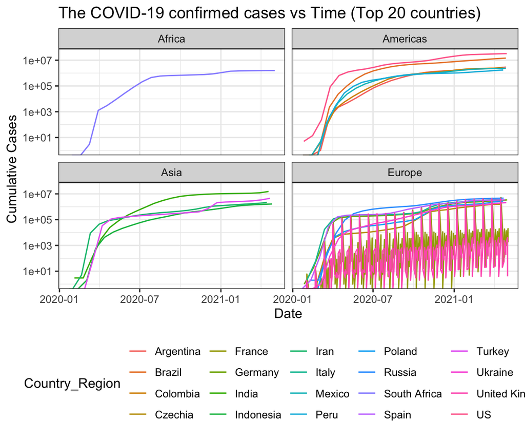

```r
confirmed <- countries20_confirmed$Country_Region
df_allp %>%
  filter(case_types == "confirmed_global", Country_Region == confirmed) %>%
  ggplot() +
  geom_line(aes(x = Date, y = cases, color = Country_Region)) +
  facet_wrap(~Continent) +
  scale_y_log10() +
  theme_bw() +
  ylab("Cumulative Cases") +
  ggtitle("The COVID-19 confirmed cases vs Time (Top 20 countries)") +
  theme(legend.position="bottom",legend.background = element_rect(fill="white",
                                  size=0.5, linetype="solid"))
```

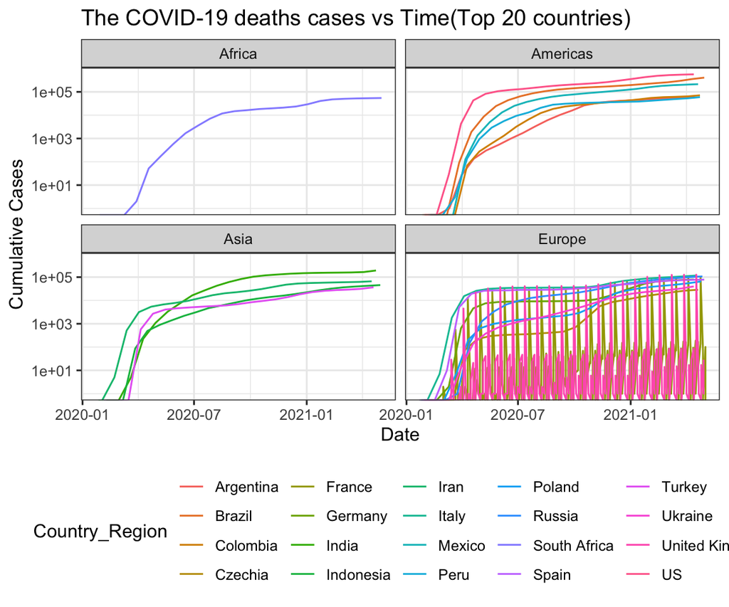

```r
deaths <- countries20_deaths$Country_Region
df_allp %>%
  filter(case_types == "deaths_global", Country_Region == deaths) %>%
  ggplot() +
  geom_line(aes(x = Date, y = cases, color = Country_Region)) +
  facet_wrap(~Continent) +
  scale_y_log10() +
  theme_bw() +
  ylab("Cumulative Cases") +
  ggtitle("The COVID-19 deaths cases vs Time(Top 20 countries)") +
    theme(legend.position="bottom", legend.background = element_rect(fill="white",
                                  size=0.5, linetype="solid"))
```